# GSB 544 PA 10.2 Penalized Regression

So far we have approached feature selection—that is, selection of which ${\bf X}$ variables to based our predictions on—by considering several subsets of features and comparing scores. But what if we want to consider *all* of the features? We don’t necessarily want to select all the features to include in our model, because we run the risk of overfitting to the training data. But maybe we want to *consider* every feature for selection rather than just a few subsets. Penalized regression is one way of performing de facto feature selection: throw all the available features into the model and let the model fitting sort out which to include.

```python
import pandas as pd
import numpy as np
from sklearn.pipeline import Pipeline
from sklearn.compose import make_column_selector, ColumnTransformer
from sklearn.preprocessing import StandardScaler, OneHotEncoder, PolynomialFeatures
from sklearn.linear_model import LinearRegression, Ridge, Lasso, ElasticNet
from sklearn.model_selection import cross_val_score
from sklearn.metrics import r2_score
```

We’ll use the Ames housing data. We’ll do a little cleaning first to:

- Drop a few columns that have mostly missing values
- Drop a few rows with missing values
- Drop the ID columns (row order and PID)

```python
ames = pd.read_csv("https://raw.githubusercontent.com/kevindavisross/data301/main/data/AmesHousing.txt", sep="\t")

# Get rid of columns with mostly NaN values
good_cols = ames.isna().sum() < 100
ames = ames.loc[:,good_cols]

# Drop other NAs
ames = ames.dropna()

# drop ID columns and put target in y
X = ames.drop(["SalePrice", "Order", "PID"], axis = 1)
y = ames["SalePrice"]

X
```

|  | MS SubClass | MS Zoning | Lot Area | Street | Lot Shape | Land Contour | Utilities | Lot Config | Land Slope | Neighborhood | ... | Open Porch SF | Enclosed Porch | 3Ssn Porch | Screen Porch | Pool Area | Misc Val | Mo Sold | Yr Sold | Sale Type | Sale Condition |
| --- | --- | --- | --- | --- | --- | --- | --- | --- | --- | --- | --- | --- | --- | --- | --- | --- | --- | --- | --- | --- | --- |
| 0 | 20 | RL | 31770 | Pave | IR1 | Lvl | AllPub | Corner | Gtl | NAmes | ... | 62 | 0 | 0 | 0 | 0 | 0 | 5 | 2010 | WD | Normal |
| 1 | 20 | RH | 11622 | Pave | Reg | Lvl | AllPub | Inside | Gtl | NAmes | ... | 0 | 0 | 0 | 120 | 0 | 0 | 6 | 2010 | WD | Normal |
| 2 | 20 | RL | 14267 | Pave | IR1 | Lvl | AllPub | Corner | Gtl | NAmes | ... | 36 | 0 | 0 | 0 | 0 | 12500 | 6 | 2010 | WD | Normal |
| 3 | 20 | RL | 11160 | Pave | Reg | Lvl | AllPub | Corner | Gtl | NAmes | ... | 0 | 0 | 0 | 0 | 0 | 0 | 4 | 2010 | WD | Normal |
| 4 | 60 | RL | 13830 | Pave | IR1 | Lvl | AllPub | Inside | Gtl | Gilbert | ... | 34 | 0 | 0 | 0 | 0 | 0 | 3 | 2010 | WD | Normal |
| ... | ... | ... | ... | ... | ... | ... | ... | ... | ... | ... | ... | ... | ... | ... | ... | ... | ... | ... | ... | ... | ... |
| 2925 | 80 | RL | 7937 | Pave | IR1 | Lvl | AllPub | CulDSac | Gtl | Mitchel | ... | 0 | 0 | 0 | 0 | 0 | 0 | 3 | 2006 | WD | Normal |
| 2926 | 20 | RL | 8885 | Pave | IR1 | Low | AllPub | Inside | Mod | Mitchel | ... | 0 | 0 | 0 | 0 | 0 | 0 | 6 | 2006 | WD | Normal |
| 2927 | 85 | RL | 10441 | Pave | Reg | Lvl | AllPub | Inside | Gtl | Mitchel | ... | 32 | 0 | 0 | 0 | 0 | 700 | 7 | 2006 | WD | Normal |
| 2928 | 20 | RL | 10010 | Pave | Reg | Lvl | AllPub | Inside | Mod | Mitchel | ... | 38 | 0 | 0 | 0 | 0 | 0 | 4 | 2006 | WD | Normal |
| 2929 | 60 | RL | 9627 | Pave | Reg | Lvl | AllPub | Inside | Mod | Mitchel | ... | 48 | 0 | 0 | 0 | 0 | 0 | 11 | 2006 | WD | Normal |

2821 rows × 67 columns

```python
y
```

```
0       215000
1       105000
2       172000
3       244000
4       189900
         ...
2925    142500
2926    131000
2927    132000
2928    170000
2929    188000
Name: SalePrice, Length: 2821, dtype: int64
```

Let’s try a linear regression model first. We’ll standardize numerical predictors and dummify categorical predictors.

```python
ct = ColumnTransformer(
  [
    ("dummify",
    OneHotEncoder(sparse_output = False, handle_unknown='ignore'),
    make_column_selector(dtype_include=object)),
    ("standardize",
    StandardScaler(),
    make_column_selector(dtype_include=np.number))
  ],
  remainder = "passthrough"
).set_output(transform="pandas")
```

```python
lr_pipeline = Pipeline(
  [("preprocessing", ct),
  ("linear_regression", LinearRegression())]
)
```

```python
lr_pipeline.fit(X, y)
```

```
Pipeline(steps=[('preprocessing',
                 ColumnTransformer(remainder='passthrough',
                                   transformers=[('dummify',
                                                  OneHotEncoder(handle_unknown='ignore',
                                                                sparse_output=False),
                                                  <sklearn.compose._column_transformer.make_column_selector object at 0x162dacad0>),
                                                 ('standardize',
                                                  StandardScaler(),
                                                  <sklearn.compose._column_transformer.make_column_selector object at 0x1627c11d0>)])),
                ('linear_regression', LinearRegression())])
```

Now let’s use cross-validation to evaluate based on $R^2$.

```python
cross_val_score(lr_pipeline, X, y, cv = 10, scoring = 'r2')
```

```
array([0.88433686, 0.90316706, 0.87507511, 0.91216037, 0.82269502,
       0.73890838, 0.86879893, 0.63798647, 0.90277443, 0.90350125])
```

Hmmm… linear regression on all the predictors does not seem as bad as the textbook suggests, though there is considerably variability between the scores based on the different folds.

Let’s add second degree polynomial terms for all numerical predictors and see what happens.

```python
numeric_poly = Pipeline([
    ("polynomial_features", PolynomialFeatures(degree=2)),
    ("standardize", StandardScaler())
])

ct_poly = ColumnTransformer(
    [
        ("dummify",
         OneHotEncoder(sparse_output=False, handle_unknown="ignore"),
         make_column_selector(dtype_include=object)),

        ("numeric_poly",
         numeric_poly,
         make_column_selector(dtype_include=np.number))
    ],
    remainder="drop"
).set_output(transform="pandas")
```

```python
poly_pipeline = Pipeline(
  [("preprocessing", ct_poly),
  ("linear_regression", LinearRegression())]
)
```

```python
poly_pipeline.fit(X, y)
```

```
Pipeline(steps=[('preprocessing',
                 ColumnTransformer(transformers=[('dummify',
                                                  OneHotEncoder(handle_unknown='ignore',
                                                                sparse_output=False),
                                                  <sklearn.compose._column_transformer.make_column_selector object at 0x162dcd9d0>),
                                                 ('numeric_poly',
                                                  Pipeline(steps=[('polynomial_features',
                                                                   PolynomialFeatures()),
                                                                  ('standardize',
                                                                   StandardScaler())]),
                                                  <sklearn.compose._column_transformer.make_column_selector object at 0x162dcd950>)])),
                ('linear_regression', LinearRegression())])
```

```python
cross_val_score(poly_pipeline, X, y, cv = 10, scoring = 'r2')
```

```
array([  0.88322049,  -0.2351045 ,  -5.18937935,   0.23576715,
       -25.57250087,   0.65934136,   0.23955858,  -1.0532801 ,
        -3.71975499, -51.70824861])
```

OK, now that’s bad. The moral is that just throwing in all the predictors might fit the training data well but can be pretty terrible when it comes to making predictions for new observations. We want to be more selective without having to laboriously search through all the possible subsets of predictors. With 67 predictors there are $2^{67}\approx 10^{20}$ possible subsets—even before we consider polynomial terms, interactions, transformations, etc—so it would be impossible to fit every possible subset.

Instead, we include all predictors but “penalize” variables that don’t contribute much to the model. Before getting to the penalty we’ll consider some motivating conceptual questions.

1. Consider a simple linear regression of sale price on a single variable like living area. What is the process by which the coefficient for living area is determined? How does “least squares” work? **DISCUSS**

Least squares determines the coefficient for living area by finding the slope and intercept that minimize the sum of squared residuals (RSS), which are the differences between actual and predicted sale prices.

2. Now consider a multiple of regression on living area and number of bedrooms, without standardizing variables. How does least squares work in this case? **DISCUSS**

Least squares works the same way as simple linear regression, but now it finds multiple coefficients simultaneously to minimize the sum of squared residuals (RSS).

3. If you fit the linear model, without standarizing variables, how do you interpret the coefficients for living area and number of bedrooms? What is their rough order of magnitude? Can we determine directly from the coefficients which variable the predicted prices are more sensitive to? **DISCUSS**

Each coefficient represents the predicted change in sale price for a one-unit increase in that variable, holding the other variables constant.

4. If you standardize the variables first, how would you interpret the model coefficients? How could you determine, roughly, which variable the predicted prices are more sensitive to? **DISCUSS**

After standardization, each coefficient represents the predicted change in sale price for a one-standard-deviation increase in that predictor, holding other variables constant.

5. If we want to make the predictions *less* sensitive to a particular standardized variable, what in principle should we do to its coefficient? **DISCUSS**

Reduce the absolute magnitude of that variable’s coefficient, bringing it closer to zero.

6. If we want to make the predictions *not at all* sensitive to a particular standardized variable, what in principle should we do to its coefficient? **DISCUSS**

Set the variable’s coefficient equal to zero. This removes its influence on predictions because changes in that variable will no longer affect the predicted outcome.

7. Why does including a penalty like in ridge regression or LASSO “shrink” coefficients towards 0? **DISCUSS**

Ridge and LASSO add a penalty for large coefficients to the ordinary least squares objective. To minimize the total objective, the model balances prediction accuracy with keeping coefficients small.

8. Why is it important to standarize variables when using a penalty? **DISCUSS**

Standardization puts all predictors on the same scale, ensuring the penalty treats them fairly.

9. What happens if the penalty parameter $\lambda$ is 0? **DISCUSS**

When lambda=0, there is no penalty, so Ridge and LASSO reduce to the ordinary least squares (OLS) objective.

10. What happens as the penalty parameter $\lambda$ gets larger and larger? **DISCUSS**

As lambda increases, regularization becomes stronger, forcing coefficients closer to zero.

11. Why do we not penalize the intercept? **DISCUSS**

The intercept represents the baseline prediction when all predictors equal zero. We do not penalize it because we want the model to freely estimate the baseline value without forcing it toward zero.

12. Assume $\lambda = 1$. Suppose a standardized predictor has a small coefficient, say $\beta = 0.1$. How much does that coefficient add to the LASSO penalty versus the ridge penalty? If the coefficient were reduced from 0.1 to 0, how much would each penalty decrease? Which penalty offers a larger payoff for eliminating a small coefficient entirely? **DISCUSS**

When lambda=1 and beta=0.1, LASSO produces a larger penalty than Ridge.

- Ridge regression shrinks all coefficient estimates toward zero but typically keeps every predictor in the model.
- LASSO regression shrinks coefficients and can set some exactly to zero, automatically removing those predictors.
- Choose ridge when predictors are highly correlated and you think many of them contain useful predictive information. Ridge tends to share influence among correlated variables.
- Choose LASSO when you want a simpler, more interpretable model with automatic variable selection.
- With highly correlated predictors, LASSO may keep one and drop the others—sometimes somewhat arbitrarily—while ridge usually retains all of them with smaller coefficients.
- Both methods are useful when there are many predictors or when ordinary least squares may overfit.

**Note that in scikit-learn the penalty parameter $\lambda$ is called `alpha`.**

## Ridge Regression

Let’s fit regression regression first.

```python
ridge_pipeline = Pipeline(
  [("preprocessing", ct),
  ("ridge_regression", Ridge(alpha=1))]
)
```

```python
ridge_pipeline.fit(X, y)
```

```
Pipeline(steps=[('preprocessing',
                 ColumnTransformer(remainder='passthrough',
                                   transformers=[('dummify',
                                                  OneHotEncoder(handle_unknown='ignore',
                                                                sparse_output=False),
                                                  <sklearn.compose._column_transformer.make_column_selector object at 0x162dacad0>),
                                                 ('standardize',
                                                  StandardScaler(),
                                                  <sklearn.compose._column_transformer.make_column_selector object at 0x1627c11d0>)])),
                ('ridge_regression', Ridge(alpha=1))])
```

```python
cross_val_score(ridge_pipeline, X, y, cv = 10, scoring = 'r2')
```

```
array([0.88714414, 0.90234101, 0.87838221, 0.92163172, 0.8345624 ,
       0.74313152, 0.86135562, 0.68453605, 0.91776347, 0.90466508])
```

There are a lot of predictors so there are a lot of coefficients. The code below is just an illustration of how the coefficients in the ridge regression model compare to the original linear regression model.

```python
coef_compare = pd.DataFrame()
coef_compare["feature"] = lr_pipeline.named_steps["preprocessing"].get_feature_names_out()

coef_compare["lr"] = lr_pipeline.named_steps['linear_regression'].coef_
coef_compare["ridge"] = ridge_pipeline.named_steps['ridge_regression'].coef_
coef_compare["diff"] = abs(coef_compare["lr"]) - abs(coef_compare["ridge"])
```

```python
coef_compare.sort_values(by = "diff", ascending=False)
```

|  | feature | lr | ridge | diff |
| --- | --- | --- | --- | --- |
| 91 | dummify__Roof Matl_ClyTile | -559653.342134 | -233156.089658 | 326497.252476 |
| 93 | dummify__Roof Matl_Membran | 119504.966230 | 32582.552859 | 86922.413371 |
| 94 | dummify__Roof Matl_Metal | 109059.255835 | 28387.663156 | 80671.592679 |
| 37 | dummify__Neighborhood_GrnHill | 127054.304996 | 66530.685838 | 60523.619159 |
| 69 | dummify__Condition 2_RRAe | 64910.291903 | 24567.527777 | 40342.764126 |
| ... | ... | ... | ... | ... |
| 9 | dummify__Lot Shape_IR2 | 3714.571039 | 7298.885203 | -3584.314165 |
| 45 | dummify__Neighborhood_NoRidge | 23073.438286 | 27838.034970 | -4764.596685 |
| 46 | dummify__Neighborhood_NridgHt | 17323.198503 | 22416.699195 | -5093.500692 |
| 111 | dummify__Exterior 1st_Stucco | -609.269882 | -5946.929666 | -5337.659785 |
| 10 | dummify__Lot Shape_IR3 | -169.659499 | -10864.716766 | -10695.057267 |

254 rows × 4 columns

Let’s add a ridge penalty to the polynomial regression

```python
ridge_poly_pipeline = Pipeline(
  [("preprocessing", ct_poly),
  ("ridge_regression", Ridge(alpha=1))]
)
```

```python
ridge_poly_pipeline.fit(X, y)
```

```
Pipeline(steps=[('preprocessing',
                 ColumnTransformer(transformers=[('dummify',
                                                  OneHotEncoder(handle_unknown='ignore',
                                                                sparse_output=False),
                                                  <sklearn.compose._column_transformer.make_column_selector object at 0x162dcd9d0>),
                                                 ('numeric_poly',
                                                  Pipeline(steps=[('polynomial_features',
                                                                   PolynomialFeatures()),
                                                                  ('standardize',
                                                                   StandardScaler())]),
                                                  <sklearn.compose._column_transformer.make_column_selector object at 0x162dcd950>)])),
                ('ridge_regression', Ridge(alpha=1))])
```

```python
cross_val_score(ridge_poly_pipeline, X, y, cv = 10, scoring = 'r2')
```

```
array([ 0.91643374,  0.91589548,  0.52803531,  0.84083074,  0.78663152,
        0.68627357,  0.85705628, -0.04182712,  0.419092  ,  0.83885314])
```

```python
poly_coef_compare = pd.DataFrame()

poly_coef_compare["feature"] = poly_pipeline.named_steps["preprocessing"].get_feature_names_out()

poly_coef_compare["lr_poly"] = poly_pipeline.named_steps["linear_regression"].coef_
poly_coef_compare["ridge_poly"] = ridge_poly_pipeline.named_steps["ridge_regression"].coef_

poly_coef_compare["diff_poly"] = (
    poly_coef_compare["lr_poly"].abs()
    - poly_coef_compare["ridge_poly"].abs()
)
```

```python
poly_coef_compare.sort_values(by = "diff_poly", ascending=False)
```

|  | feature | lr_poly | ridge_poly | diff_poly |
| --- | --- | --- | --- | --- |
| 794 | numeric_poly__Garage Cars Yr Sold | 3.387006e+06 | -4620.485750 | 3.382386e+06 |
| 244 | numeric_poly__Garage Cars | -3.245972e+06 | -5390.912549 | 3.240581e+06 |
| 834 | numeric_poly__3Ssn Porch Yr Sold | -3.033907e+06 | 2595.063963 | 3.031312e+06 |
| 804 | numeric_poly__Garage Area Yr Sold | -2.974090e+06 | -4376.452692 | 2.969713e+06 |
| 245 | numeric_poly__Garage Area | 2.798078e+06 | -4469.165800 | 2.793609e+06 |
| ... | ... | ... | ... | ... |
| 51 | dummify__Neighborhood_Somerst | 1.597666e+03 | 6782.704918 | -5.185039e+03 |
| 46 | dummify__Neighborhood_NridgHt | 3.863365e+03 | 9412.370927 | -5.549006e+03 |
| 334 | numeric_poly__Overall Qual Gr Liv Area | 5.111578e+03 | 11990.016265 | -6.878439e+03 |
| 739 | numeric_poly__Bedroom AbvGr 3Ssn Porch | 7.009193e+03 | 14597.269287 | -7.588076e+03 |
| 68 | dummify__Condition 2_PosN | -3.045916e+04 | -41557.725371 | -1.109857e+04 |

850 rows × 4 columns

## LASSO

Now let’s try LASSO

```python
lasso_pipeline = Pipeline(
  [("preprocessing", ct),
  ("lasso_regression", Lasso(alpha=1))]
)
```

```python
lasso_pipeline.fit(X, y)
```

```
Pipeline(steps=[('preprocessing',
                 ColumnTransformer(remainder='passthrough',
                                   transformers=[('dummify',
                                                  OneHotEncoder(handle_unknown='ignore',
                                                                sparse_output=False),
                                                  <sklearn.compose._column_transformer.make_column_selector object at 0x162dacad0>),
                                                 ('standardize',
                                                  StandardScaler(),
                                                  <sklearn.compose._column_transformer.make_column_selector object at 0x1627c11d0>)])),
                ('lasso_regression', Lasso(alpha=1))])
```

```python
cross_val_score(lasso_pipeline, X, y, cv = 10, scoring = 'r2')
```

```
array([0.88518658, 0.90350535, 0.87598015, 0.91272267, 0.84018431,
       0.74897011, 0.87210755, 0.6385441 , 0.90335199, 0.91467053])
```

```python
coef_compare["lasso"] = lasso_pipeline.named_steps['lasso_regression'].coef_
coef_compare["ridge_lasso_diff"] = abs(coef_compare["ridge"]) - abs(coef_compare["lasso"])
```

```python
coef_compare.sort_values(by = "ridge_lasso_diff", ascending=False)
```

|  | feature | lr | ridge | diff | lasso | ridge_lasso_diff |
| --- | --- | --- | --- | --- | --- | --- |
| 126 | dummify__Exterior 2nd_PreCast | 37584.951869 | 25708.646790 | 11876.305079 | 623.765038 | 25084.881752 |
| 98 | dummify__Roof Matl_WdShngl | 118966.036255 | 83910.181360 | 35055.854896 | 58830.723632 | 25079.457727 |
| 96 | dummify__Roof Matl_Tar&Grv | 61103.839805 | 24715.717943 | 36388.121863 | 12.313931 | 24703.404012 |
| 95 | dummify__Roof Matl_Roll | 55399.766568 | 16828.505080 | 38571.261487 | -987.398326 | 15841.106754 |
| 92 | dummify__Roof Matl_CompShg | 47815.565877 | 26802.263636 | 21013.302241 | -11572.161484 | 15230.102152 |
| ... | ... | ... | ... | ... | ... | ... |
| 68 | dummify__Condition 2_PosN | -113384.181772 | -77996.160321 | 35388.021451 | -111624.851127 | -33628.690806 |
| 69 | dummify__Condition 2_RRAe | 64910.291903 | 24567.527777 | 40342.764126 | 60878.855589 | -36311.327812 |
| 109 | dummify__Exterior 1st_PreCast | 37584.951869 | 25708.646790 | 11876.305079 | 76167.305679 | -50458.658888 |
| 37 | dummify__Neighborhood_GrnHill | 127054.304996 | 66530.685838 | 60523.619159 | 132015.733845 | -65485.048008 |
| 91 | dummify__Roof Matl_ClyTile | -559653.342134 | -233156.089658 | 326497.252476 | -614586.359691 | -381430.270032 |

254 rows × 6 columns

How many ridge coefficients are 0?

```python
(coef_compare["ridge"] == 0).sum()
```

```
np.int64(0)
```

How many LASSO coefficients are 0?

```python
(coef_compare["lasso"] == 0).sum()
```

```
np.int64(24)
```

Let’s add a lasso penalty to the polynomial regression

```python
lasso_poly_pipeline = Pipeline(
  [("preprocessing", ct_poly),
  ("lasso_regression", Lasso(alpha=1))]
)
```

```python
lasso_poly_pipeline.fit(X, y)
```

```
Pipeline(steps=[('preprocessing',
                 ColumnTransformer(transformers=[('dummify',
                                                  OneHotEncoder(handle_unknown='ignore',
                                                                sparse_output=False),
                                                  <sklearn.compose._column_transformer.make_column_selector object at 0x162dcd9d0>),
                                                 ('numeric_poly',
                                                  Pipeline(steps=[('polynomial_features',
                                                                   PolynomialFeatures()),
                                                                  ('standardize',
                                                                   StandardScaler())]),
                                                  <sklearn.compose._column_transformer.make_column_selector object at 0x162dcd950>)])),
                ('lasso_regression', Lasso(alpha=1))])
```

```python
cross_val_score(lasso_poly_pipeline, X, y, cv = 10, scoring = 'r2')
```

[output not shown]

```
array([ 0.90979667,  0.92702486,  0.44652545,  0.78533568,  0.77909959,
        0.82331629,  0.85113281, -0.85238606, -0.07422078,  0.86454442])
```

```python
poly_coef_compare["lasso_poly"] = lasso_poly_pipeline.named_steps["lasso_regression"].coef_

poly_coef_compare["ridge_lasso_diff_poly"] = (
    poly_coef_compare["ridge_poly"].abs()
    - poly_coef_compare["lasso_poly"].abs()
)
```

```python
poly_coef_compare.sort_values(by = "ridge_lasso_diff_poly", ascending=False)
```

|  | feature | lr_poly | ridge_poly | diff_poly | lasso_poly | ridge_lasso_diff_poly |
| --- | --- | --- | --- | --- | --- | --- |
| 126 | dummify__Exterior 2nd_PreCast | 46508.615317 | 26111.675137 | 20396.940181 | 1934.238609 | 24177.436528 |
| 302 | numeric_poly__Lot Area Gr Liv Area | -26349.340528 | -22033.486849 | 4315.853679 | 458.529117 | 21574.957732 |
| 330 | numeric_poly__Overall Qual Total Bsmt SF | 44213.087679 | 27183.859599 | 17029.228080 | 9036.333895 | 18147.525704 |
| 769 | numeric_poly__TotRms AbvGrd Misc Val | 48926.675238 | 15902.289844 | 33024.385394 | -3821.078063 | 12081.211781 |
| 334 | numeric_poly__Overall Qual Gr Liv Area | 5111.577636 | 11990.016265 | -6878.438630 | -0.000000 | 11990.016265 |
| ... | ... | ... | ... | ... | ... | ... |
| 94 | dummify__Roof Matl_Metal | 15115.740454 | 10325.802612 | 4789.937841 | 45438.678668 | -35112.876056 |
| 100 | dummify__Exterior 1st_AsphShn | -45377.934301 | -13686.992691 | 31690.941610 | -49426.340005 | -35739.347314 |
| 223 | numeric_poly__Overall Qual | -61342.056286 | -3803.537261 | 57538.519024 | 40803.262534 | -36999.725273 |
| 109 | dummify__Exterior 1st_PreCast | 46508.615317 | 26111.675137 | 20396.940181 | 95628.406450 | -69516.731313 |
| 37 | dummify__Neighborhood_GrnHill | 120750.216392 | 55234.495430 | 65515.720962 | 132347.102779 | -77112.607349 |

850 rows × 6 columns

How many ridge coefficients are 0?

```python
(poly_coef_compare["ridge_poly"] == 0).sum()
```

```
np.int64(4)
```

How many LASSO coefficients are 0?

```python
(poly_coef_compare["lasso_poly"] == 0).sum()
```

```
np.int64(51)
```

## Grid search on `alpha` parameter

Note that useful values of `alpha` to consider depend on the scale of the $y$ variable.

```python
from sklearn.model_selection import GridSearchCV

lasso_pipeline = Pipeline(
  [("preprocessing", ct),
  ("lasso_regression", Lasso(alpha = 1))]
).set_output(transform="pandas")

alphas = {'lasso_regression__alpha': np.array([10000, 1000, 100, 10, 1])}

gscv = GridSearchCV(lasso_pipeline, param_grid=alphas, cv = 10, scoring='r2')
```

```python
gscv_fitted = gscv.fit(X, y)

gscv_fitted.cv_results_
```

```
{'mean_fit_time': array([0.03414948, 0.04766922, 0.16614375, 0.16013823, 0.46417866]),
 'std_fit_time': array([0.00417892, 0.00389811, 0.02265642, 0.04250107, 0.08455208]),
 'mean_score_time': array([0.00742965, 0.0074512 , 0.0096128 , 0.00847075, 0.00939221]),
 'std_score_time': array([0.00266185, 0.00202345, 0.00559971, 0.002642  , 0.00331909]),
 'param_lasso_regression__alpha': masked_array(data=[10000, 1000, 100, 10, 1],
              mask=[False, False, False, False, False],
        fill_value=999999),
 'params': [{'lasso_regression__alpha': np.int64(10000)},
  {'lasso_regression__alpha': np.int64(1000)},
  {'lasso_regression__alpha': np.int64(100)},
  {'lasso_regression__alpha': np.int64(10)},
  {'lasso_regression__alpha': np.int64(1)}],
 'split0_test_score': array([0.77315012, 0.86355064, 0.89380717, 0.89168592, 0.88518658]),
 'split1_test_score': array([0.74147501, 0.87197583, 0.90424468, 0.90485654, 0.90350535]),
 'split2_test_score': array([0.73671146, 0.81703649, 0.88225665, 0.87886619, 0.87598015]),
 'split3_test_score': array([0.79242561, 0.91421561, 0.92861225, 0.91711772, 0.91272267]),
 'split4_test_score': array([0.72736689, 0.83506012, 0.86677831, 0.85054577, 0.84018431]),
 'split5_test_score': array([0.67248798, 0.70887955, 0.75000894, 0.75342211, 0.74897011]),
 'split6_test_score': array([0.76942016, 0.83161339, 0.85790944, 0.87254731, 0.87210755]),
 'split7_test_score': array([0.64971871, 0.66002259, 0.6750123 , 0.64612869, 0.6385441 ]),
 'split8_test_score': array([0.81012394, 0.91397078, 0.92232006, 0.90705106, 0.90335199]),
 'split9_test_score': array([0.76366351, 0.85561738, 0.90734979, 0.91698341, 0.91467053]),
 'mean_test_score': array([0.74365434, 0.82719424, 0.85882996, 0.85392047, 0.84952233]),
 'std_test_score': array([0.0478935 , 0.07833725, 0.07796436, 0.08310979, 0.08440508]),
 'rank_test_score': array([5, 4, 1, 2, 3], dtype=int32)}
```

```python
df_cv_results_ = pd.DataFrame(gscv_fitted.cv_results_)

df_cv_results_
```

|  | mean_fit_time | std_fit_time | mean_score_time | std_score_time | param_lasso_regression__alpha | params | split0_test_score | split1_test_score | split2_test_score | split3_test_score | split4_test_score | split5_test_score | split6_test_score | split7_test_score | split8_test_score | split9_test_score | mean_test_score | std_test_score | rank_test_score |
| --- | --- | --- | --- | --- | --- | --- | --- | --- | --- | --- | --- | --- | --- | --- | --- | --- | --- | --- | --- |
| 0 | 0.034149 | 0.004179 | 0.007430 | 0.002662 | 10000 | {'lasso_regression__alpha': 10000} | 0.773150 | 0.741475 | 0.736711 | 0.792426 | 0.727367 | 0.672488 | 0.769420 | 0.649719 | 0.810124 | 0.763664 | 0.743654 | 0.047894 | 5 |
| 1 | 0.047669 | 0.003898 | 0.007451 | 0.002023 | 1000 | {'lasso_regression__alpha': 1000} | 0.863551 | 0.871976 | 0.817036 | 0.914216 | 0.835060 | 0.708880 | 0.831613 | 0.660023 | 0.913971 | 0.855617 | 0.827194 | 0.078337 | 4 |
| 2 | 0.166144 | 0.022656 | 0.009613 | 0.005600 | 100 | {'lasso_regression__alpha': 100} | 0.893807 | 0.904245 | 0.882257 | 0.928612 | 0.866778 | 0.750009 | 0.857909 | 0.675012 | 0.922320 | 0.907350 | 0.858830 | 0.077964 | 1 |
| 3 | 0.160138 | 0.042501 | 0.008471 | 0.002642 | 10 | {'lasso_regression__alpha': 10} | 0.891686 | 0.904857 | 0.878866 | 0.917118 | 0.850546 | 0.753422 | 0.872547 | 0.646129 | 0.907051 | 0.916983 | 0.853920 | 0.083110 | 2 |
| 4 | 0.464179 | 0.084552 | 0.009392 | 0.003319 | 1 | {'lasso_regression__alpha': 1} | 0.885187 | 0.903505 | 0.875980 | 0.912723 | 0.840184 | 0.748970 | 0.872108 | 0.638544 | 0.903352 | 0.914671 | 0.849522 | 0.084405 | 3 |

## Elastic Net

- Elastic net combines ridge and LASSO penalties, so it both shrinks coefficients and can set some coefficients exactly to zero.
- It is often preferred when you want variable selection but also have strongly correlated predictors.
- Unlike LASSO, elastic net tends to keep correlated predictors together rather than choosing one and discarding the others.
- It has two tuning choices: the overall penalty strength and the balance between ridge-like shrinkage and LASSO-like variable selection.
- Think of it as a middle ground: ridge keeps all predictors, LASSO selects a sparse subset, and elastic net can select groups of useful predictors while dropping clearly unhelpful ones.

```python
elastic_pipeline = Pipeline(
  [("preprocessing", ct),
  ("elastic_net", ElasticNet(alpha=1, l1_ratio=0.5))]
)
```

```python
cross_val_score(elastic_pipeline, X, y, cv = 10, scoring = 'r2')
```

```
array([0.85554118, 0.84071839, 0.85482838, 0.88754895, 0.85075165,
       0.72374365, 0.80725486, 0.66306372, 0.89132019, 0.84737846])
```

```python
elastic_pipeline.fit(X, y)
```

```
Pipeline(steps=[('preprocessing',
                 ColumnTransformer(remainder='passthrough',
                                   transformers=[('dummify',
                                                  OneHotEncoder(handle_unknown='ignore',
                                                                sparse_output=False),
                                                  <sklearn.compose._column_transformer.make_column_selector object at 0x162dacad0>),
                                                 ('standardize',
                                                  StandardScaler(),
                                                  <sklearn.compose._column_transformer.make_column_selector object at 0x1627c11d0>)])),
                ('elastic_net', ElasticNet(alpha=1))])
```

## Elastic Net: Grid search

```python
elastic_pipeline_1 = Pipeline(
  [("preprocessing", ct),
  ("elastic_net", ElasticNet())]
).set_output(transform="pandas")

param_grid = {
    "elastic_net__alpha": [1, 10, 100],
    "elastic_net__l1_ratio": np.arange(0.0, 1.2, 0.2),
}

gscv = GridSearchCV(elastic_pipeline_1, param_grid=param_grid, cv = 5, scoring='r2')
```

```python
gscv_fitted = gscv.fit(X, y)

gscv_fitted.cv_results_
```

[output not shown]

[output cut: 23 more lines]

[output not shown]

```
{'mean_fit_time': array([0.57100663, 0.05068507, 0.06011319, 0.04781523, 0.05677333,
        0.45368423, 0.53077974, 0.02805476, 0.03105235, 0.03485603,
        0.0423058 , 0.16929154, 0.58418965, 0.02551208, 0.03117914,
        0.02754054, 0.0308948 , 0.12937284]),
 'std_fit_time': array([0.08450727, 0.00760476, 0.01693947, 0.01031812, 0.00671239,
        0.06792791, 0.03949317, 0.00327097, 0.00640829, 0.00477232,
        0.00951494, 0.10409201, 0.04513709, 0.0016655 , 0.00569582,
        0.00389162, 0.00546151, 0.00874745]),
 'mean_score_time': array([0.01821413, 0.0118752 , 0.00920944, 0.00852919, 0.01215925,
        0.00950565, 0.01496205, 0.01229911, 0.01059651, 0.00911417,
        0.01028681, 0.00961556, 0.01430712, 0.01076837, 0.01007891,
        0.01375484, 0.0080864 , 0.00761151]),
 'std_score_time': array([0.00311849, 0.00426716, 0.00242569, 0.00331607, 0.004995  ,
        0.00336831, 0.0024337 , 0.0055298 , 0.00145161, 0.00302629,
        0.00284524, 0.0023137 , 0.00463111, 0.00251246, 0.00305975,
        0.00065146, 0.00229037, 0.00148216]),
 'param_elastic_net__alpha': masked_array(data=[1, 1, 1, 1, 1, 1, 10, 10, 10, 10, 10, 10, 100, 100,
                    100, 100, 100, 100],
              mask=[False, False, False, False, False, False, False, False,
                    False, False, False, False, False, False, False, False,
                    False, False],
        fill_value=999999),
 'param_elastic_net__l1_ratio': masked_array(data=[0.0, 0.2, 0.4, 0.6000000000000001, 0.8, 1.0, 0.0, 0.2,
                    0.4, 0.6000000000000001, 0.8, 1.0, 0.0, 0.2, 0.4,
                    0.6000000000000001, 0.8, 1.0],
              mask=[False, False, False, False, False, False, False, False,
                    False, False, False, False, False, False, False, False,
                    False, False],
        fill_value=1e+20),
 'params': [{'elastic_net__alpha': 1,
   'elastic_net__l1_ratio': np.float64(0.0)},
  {'elastic_net__alpha': 1, 'elastic_net__l1_ratio': np.float64(0.2)},
  {'elastic_net__alpha': 1, 'elastic_net__l1_ratio': np.float64(0.4)},
  {'elastic_net__alpha': 1,
   'elastic_net__l1_ratio': np.float64(0.6000000000000001)},
  {'elastic_net__alpha': 1, 'elastic_net__l1_ratio': np.float64(0.8)},
  {'elastic_net__alpha': 1, 'elastic_net__l1_ratio': np.float64(1.0)},
  {'elastic_net__alpha': 10, 'elastic_net__l1_ratio': np.float64(0.0)},
  {'elastic_net__alpha': 10, 'elastic_net__l1_ratio': np.float64(0.2)},
  {'elastic_net__alpha': 10, 'elastic_net__l1_ratio': np.float64(0.4)},
```

[output cut: 26 more lines]

```
        0.2208233 , 0.35530277, 0.78348547]),
 'split4_test_score': array([0.85782245, 0.86661817, 0.8760215 , 0.88649791, 0.89922134,
        0.90589888, 0.56397157, 0.61521591, 0.67448987, 0.74225651,
        0.81729388, 0.90924976, 0.10564   , 0.13075171, 0.16979416,
        0.23868218, 0.39139693, 0.91954689]),
 'mean_test_score': array([0.81213194, 0.81933722, 0.82678872, 0.83483617, 0.84460235,
        0.85715222, 0.53627566, 0.58525824, 0.64190303, 0.70644635,
        0.77657868, 0.86063224, 0.09992892, 0.12374786, 0.16079791,
        0.226225  , 0.37153569, 0.86693111]),
 'std_test_score': array([0.05150617, 0.05352299, 0.05590167, 0.05872575, 0.06193892,
        0.0590181 , 0.0329539 , 0.0344734 , 0.03631915, 0.0390304 ,
        0.04485095, 0.05915673, 0.01612643, 0.01714535, 0.01874549,
        0.02155375, 0.02738249, 0.06006878]),
 'rank_test_score': array([ 8,  7,  6,  5,  4,  3, 13, 12, 11, 10,  9,  2, 18, 17, 16, 15, 14,
         1], dtype=int32)}
```

```python
df_cv_results_ = pd.DataFrame(gscv_fitted.cv_results_)

df_cv_results_
```

|  | mean_fit_time | std_fit_time | mean_score_time | std_score_time | param_elastic_net__alpha | param_elastic_net__l1_ratio | params | split0_test_score | split1_test_score | split2_test_score | split3_test_score | split4_test_score | mean_test_score | std_test_score | rank_test_score |
| --- | --- | --- | --- | --- | --- | --- | --- | --- | --- | --- | --- | --- | --- | --- | --- |
| 0 | 0.571007 | 0.084507 | 0.018214 | 0.003118 | 1 | 0.0 | {'elastic_net__alpha': 1, 'elastic_net__l1_rat... | 0.819310 | 0.873470 | 0.775538 | 0.734519 | 0.857822 | 0.812132 | 0.051506 | 8 |
| 1 | 0.050685 | 0.007605 | 0.011875 | 0.004267 | 1 | 0.2 | {'elastic_net__alpha': 1, 'elastic_net__l1_rat... | 0.830470 | 0.881659 | 0.778866 | 0.739074 | 0.866618 | 0.819337 | 0.053523 | 7 |
| 2 | 0.060113 | 0.016939 | 0.009209 | 0.002426 | 1 | 0.4 | {'elastic_net__alpha': 1, 'elastic_net__l1_rat... | 0.842222 | 0.890269 | 0.781719 | 0.743712 | 0.876022 | 0.826789 | 0.055902 | 6 |
| 3 | 0.047815 | 0.010318 | 0.008529 | 0.003316 | 1 | 0.6 | {'elastic_net__alpha': 1, 'elastic_net__l1_rat... | 0.854984 | 0.899709 | 0.784092 | 0.748899 | 0.886498 | 0.834836 | 0.058726 | 5 |
| 4 | 0.056773 | 0.006712 | 0.012159 | 0.004995 | 1 | 0.8 | {'elastic_net__alpha': 1, 'elastic_net__l1_rat... | 0.869985 | 0.910922 | 0.786466 | 0.756417 | 0.899221 | 0.844602 | 0.061939 | 4 |
| 5 | 0.453684 | 0.067928 | 0.009506 | 0.003368 | 1 | 1.0 | {'elastic_net__alpha': 1, 'elastic_net__l1_rat... | 0.897744 | 0.910938 | 0.796918 | 0.774262 | 0.905899 | 0.857152 | 0.059018 | 3 |
| 6 | 0.530780 | 0.039493 | 0.014962 | 0.002434 | 10 | 0.0 | {'elastic_net__alpha': 10, 'elastic_net__l1_ra... | 0.492511 | 0.578344 | 0.541161 | 0.505391 | 0.563972 | 0.536276 | 0.032954 | 13 |
| 7 | 0.028055 | 0.003271 | 0.012299 | 0.005530 | 10 | 0.2 | {'elastic_net__alpha': 10, 'elastic_net__l1_ra... | 0.543978 | 0.630330 | 0.587613 | 0.549154 | 0.615216 | 0.585258 | 0.034473 | 12 |
| 8 | 0.031052 | 0.006408 | 0.010597 | 0.001452 | 10 | 0.4 | {'elastic_net__alpha': 10, 'elastic_net__l1_ra... | 0.605470 | 0.690470 | 0.640126 | 0.598959 | 0.674490 | 0.641903 | 0.036319 | 11 |
| 9 | 0.034856 | 0.004772 | 0.009114 | 0.003026 | 10 | 0.6 | {'elastic_net__alpha': 10, 'elastic_net__l1_ra... | 0.679356 | 0.759111 | 0.697470 | 0.654039 | 0.742257 | 0.706446 | 0.039030 | 10 |
| 10 | 0.042306 | 0.009515 | 0.010287 | 0.002845 | 10 | 0.8 | {'elastic_net__alpha': 10, 'elastic_net__l1_ra... | 0.767995 | 0.834319 | 0.753485 | 0.709800 | 0.817294 | 0.776579 | 0.044851 | 9 |
| 11 | 0.169292 | 0.104092 | 0.009616 | 0.002314 | 10 | 1.0 | {'elastic_net__alpha': 10, 'elastic_net__l1_ra... | 0.900776 | 0.915067 | 0.801420 | 0.776649 | 0.909250 | 0.860632 | 0.059157 | 2 |
| 12 | 0.584190 | 0.045137 | 0.014307 | 0.004631 | 100 | 0.0 | {'elastic_net__alpha': 100, 'elastic_net__l1_r... | 0.068602 | 0.114533 | 0.107924 | 0.102946 | 0.105640 | 0.099929 | 0.016126 | 18 |
| 13 | 0.025512 | 0.001666 | 0.010768 | 0.002512 | 100 | 0.2 | {'elastic_net__alpha': 100, 'elastic_net__l1_r... | 0.090762 | 0.139899 | 0.132094 | 0.125232 | 0.130752 | 0.123748 | 0.017145 | 17 |
| 14 | 0.031179 | 0.005696 | 0.010079 | 0.003060 | 100 | 0.4 | {'elastic_net__alpha': 100, 'elastic_net__l1_r... | 0.125392 | 0.179344 | 0.169608 | 0.159851 | 0.169794 | 0.160798 | 0.018745 | 16 |
| 15 | 0.027541 | 0.003892 | 0.013755 | 0.000651 | 100 | 0.6 | {'elastic_net__alpha': 100, 'elastic_net__l1_r... | 0.187065 | 0.248971 | 0.235584 | 0.220823 | 0.238682 | 0.226225 | 0.021554 | 15 |
| 16 | 0.030895 | 0.005462 | 0.008086 | 0.002290 | 100 | 0.8 | {'elastic_net__alpha': 100, 'elastic_net__l1_r... | 0.326931 | 0.403467 | 0.380581 | 0.355303 | 0.391397 | 0.371536 | 0.027382 | 14 |
| 17 | 0.129373 | 0.008747 | 0.007612 | 0.001482 | 100 | 1.0 | {'elastic_net__alpha': 100, 'elastic_net__l1_r... | 0.901800 | 0.924433 | 0.805390 | 0.783485 | 0.919547 | 0.866931 | 0.060069 | 1 |

```python
y_pred = gscv_fitted.predict(X)
```

```python
target = pd.DataFrame()

target["actual"] = y
target["predicted"] = y_pred

target
```

|  | actual | predicted |
| --- | --- | --- |
| 0 | 215000 | 218388.243679 |
| 1 | 105000 | 117726.828123 |
| 2 | 172000 | 65809.498269 |
| 3 | 244000 | 274770.257070 |
| 4 | 189900 | 179516.735946 |
| ... | ... | ... |
| 2925 | 142500 | 158534.160801 |
| 2926 | 131000 | 138474.266725 |
| 2927 | 132000 | 107452.537001 |
| 2928 | 170000 | 176715.713297 |
| 2929 | 188000 | 229933.488595 |

2821 rows × 2 columns

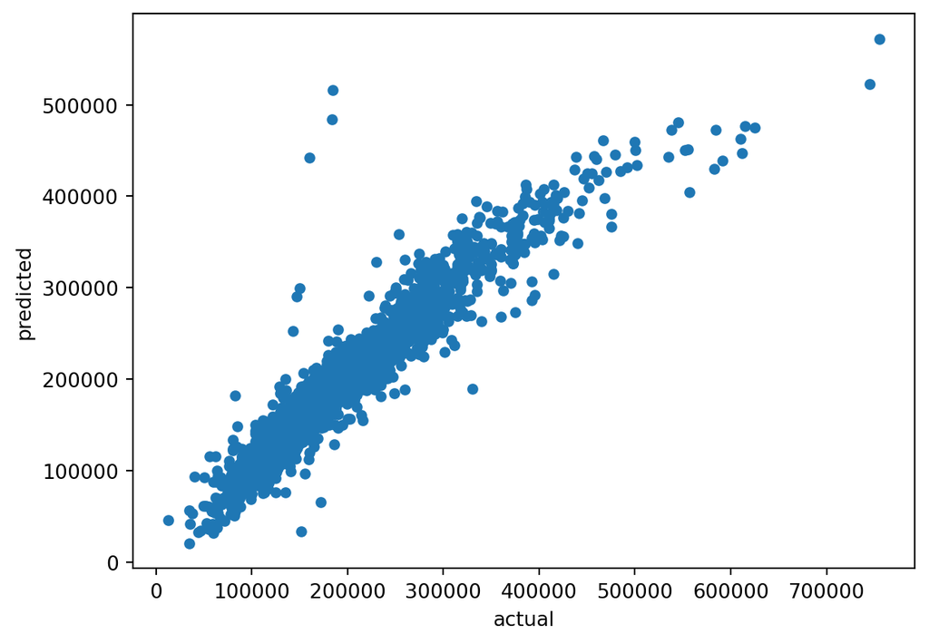

```python
target.plot.scatter(x = "actual", y = "predicted")
```

## Loans Data

The loans data set represents thousands of loans made through the Lending Club platform, which is a platform that allows individuals to lend to other individuals. Of course, not all loans are created equal. Someone who is a essentially a sure bet to pay back a loan will have an easier time getting a loan with a low interest rate than someone who appears to be riskier. And for people who are very risky? They may not even get a loan offer, or they may not have accepted the loan offer due to a high interest rate. It is important to keep that last part in mind, since this dataset only represents loans actually made, i.e. do not mistake this data for loan applications!

[Some information about the data set is here](https://openintrostat.github.io/openintro/reference/loans_full_schema.html). There are also some related exercises in this [OpenIntro textbook](https://openintro-ims.netlify.app/inf-model-mlr.html).

**Our goal will be to develop a regression model for predicting `interest_rate`.**

We will have a competition to see who can come up with the model with the smallest test RMSE. Fit several models and try to find the smallest test RMSE. When you think you have a good one, share your model and its test RMSE. Then see what other people have done; can you do even better?

**Previously you considered selected subsets of features. Now you should try, Ridge, LASSO, and elastic net.**

You should use `GridSearchCV` to tune at least one parameter.

Note: you should do some exploration of the data first before you start fitting models.

```python
df = pd.read_csv("https://raw.githubusercontent.com/kevindavisross/data301/refs/heads/main/data/loans_full_schema.csv")

df
```

|  | Unnamed: 0 | emp_title | emp_length | state | homeownership | annual_income | verified_income | debt_to_income | annual_income_joint | verification_income_joint | ... | sub_grade | issue_month | loan_status | initial_listing_status | disbursement_method | balance | paid_total | paid_principal | paid_interest | paid_late_fees |
| --- | --- | --- | --- | --- | --- | --- | --- | --- | --- | --- | --- | --- | --- | --- | --- | --- | --- | --- | --- | --- | --- |
| 0 | 1 | global config engineer | 3.0 | NJ | MORTGAGE | 90000.0 | Verified | 18.01 | NaN | NaN | ... | C3 | Mar-2018 | Current | whole | Cash | 27015.86 | 1999.33 | 984.14 | 1015.19 | 0.0 |
| 1 | 2 | warehouse office clerk | 10.0 | HI | RENT | 40000.0 | Not Verified | 5.04 | NaN | NaN | ... | C1 | Feb-2018 | Current | whole | Cash | 4651.37 | 499.12 | 348.63 | 150.49 | 0.0 |
| 2 | 3 | assembly | 3.0 | WI | RENT | 40000.0 | Source Verified | 21.15 | NaN | NaN | ... | D1 | Feb-2018 | Current | fractional | Cash | 1824.63 | 281.80 | 175.37 | 106.43 | 0.0 |
| 3 | 4 | customer service | 1.0 | PA | RENT | 30000.0 | Not Verified | 10.16 | NaN | NaN | ... | A3 | Jan-2018 | Current | whole | Cash | 18853.26 | 3312.89 | 2746.74 | 566.15 | 0.0 |
| 4 | 5 | security supervisor | 10.0 | CA | RENT | 35000.0 | Verified | 57.96 | 57000.0 | Verified | ... | C3 | Mar-2018 | Current | whole | Cash | 21430.15 | 2324.65 | 1569.85 | 754.80 | 0.0 |
| ... | ... | ... | ... | ... | ... | ... | ... | ... | ... | ... | ... | ... | ... | ... | ... | ... | ... | ... | ... | ... | ... |
| 9995 | 9996 | owner | 10.0 | TX | RENT | 108000.0 | Source Verified | 22.28 | NaN | NaN | ... | A4 | Jan-2018 | Current | whole | Cash | 21586.34 | 2969.80 | 2413.66 | 556.14 | 0.0 |
| 9996 | 9997 | director | 8.0 | PA | MORTGAGE | 121000.0 | Verified | 32.38 | NaN | NaN | ... | D3 | Feb-2018 | Current | whole | Cash | 9147.44 | 1456.31 | 852.56 | 603.75 | 0.0 |
| 9997 | 9998 | toolmaker | 10.0 | CT | MORTGAGE | 67000.0 | Verified | 45.26 | 107000.0 | Source Verified | ... | E2 | Feb-2018 | Current | fractional | Cash | 27617.65 | 4620.80 | 2382.35 | 2238.45 | 0.0 |
| 9998 | 9999 | manager | 1.0 | WI | MORTGAGE | 80000.0 | Source Verified | 11.99 | NaN | NaN | ... | A1 | Feb-2018 | Current | whole | Cash | 21518.12 | 2873.31 | 2481.88 | 391.43 | 0.0 |
| 9999 | 10000 | operations analyst | 3.0 | CT | RENT | 66000.0 | Not Verified | 20.82 | NaN | NaN | ... | B4 | Feb-2018 | Current | whole | Cash | 11574.83 | 1658.56 | 1225.17 | 433.39 | 0.0 |

10000 rows × 56 columns

```
Dataset Shape:
(10000, 56)

Column Names:
['Unnamed: 0', 'emp_title', 'emp_length', 'state', 'homeownership', 'annual_income', 'verified_income', 'debt_to_income', 'annual_income_joint', 'verification_income_joint', 'debt_to_income_joint', 'delinq_2y', 'months_since_last_delinq', 'earliest_credit_line', 'inquiries_last_12m', 'total_credit_l…

Target Variable Summary:
count    10000.000000
mean        12.427524
std          5.001105
min          5.310000
25%          9.430000
50%         11.980000
75%         15.050000
max         30.940000
Name: interest_rate, dtype: float64

Missing Values:
verification_income_joint           8545
annual_income_joint                 8505
debt_to_income_joint                8505
months_since_90d_late               7715
months_since_last_delinq            5658
months_since_last_credit_inquiry    1271
emp_title                            833
emp_length                           817
num_accounts_120d_past_due           318
debt_to_income                        24
interest_rate                          0
tax_liens                              0
account_never_delinq_percent           0
public_record_bankrupt                 0
loan_purpose                           0
application_type                       0
loan_amount                            0
num_mort_accounts                      0
term                                   0
sub_grade                              0
installment                            0
grade                                  0
```

[output cut: 31 more lines]

```
num_accounts_30d_past_due              0
num_active_debit_accounts              0
paid_late_fees                         0
dtype: int64

Data Types:
int64      26
float64    17
object     13
Name: count, dtype: int64

Duplicate Rows:
0

Interest Rate Distribution:
```

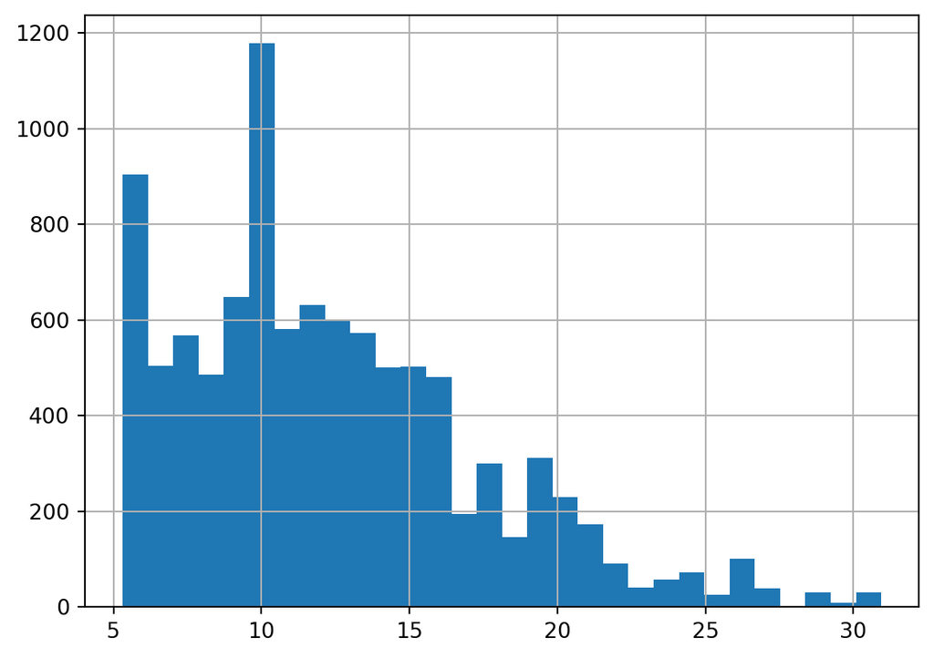

```python
# Practice Activity: Explore Loans Data

print("Dataset Shape:")
print(df.shape)

print("\nColumn Names:")
print(df.columns.tolist())

print("\nTarget Variable Summary:")
print(df["interest_rate"].describe())

print("\nMissing Values:")
print(df.isnull().sum().sort_values(ascending=False))

print("\nData Types:")
print(df.dtypes.value_counts())

print("\nDuplicate Rows:")
print(df.duplicated().sum())

print("\nInterest Rate Distribution:")
df["interest_rate"].hist(bins=30)
```

```python
# Practice Activity: Baseline Linear Regression

import numpy as np
import pandas as pd

from sklearn.model_selection import train_test_split
from sklearn.compose import ColumnTransformer
from sklearn.pipeline import Pipeline
from sklearn.preprocessing import StandardScaler, OneHotEncoder
from sklearn.impute import SimpleImputer
from sklearn.linear_model import LinearRegression
from sklearn.metrics import mean_squared_error

# Remove target and columns that may cause leakage
drop_cols = [
    "interest_rate",
    "Unnamed: 0",
    "installment",
    "grade",
    "sub_grade",
    "loan_status",
    "balance",
    "paid_total",
    "paid_principal",
    "paid_interest",
    "paid_late_fees",
    "emp_title",
    "earliest_credit_line",
    "issue_month",
    "initial_listing_status",
    "disbursement_method"
]

X = df.drop(columns=drop_cols)
y = df["interest_rate"]

# Train/test split
X_train, X_test, y_train, y_test = train_test_split(
    X, y, test_size=0.20, random_state=42
)

# Identify numerical and categorical columns
num_cols = X.select_dtypes(include=np.number).columns
cat_cols = X.select_dtypes(exclude=np.number).columns

# Numerical preprocessing
num_transformer = Pipeline([
    ("imputer", SimpleImputer(strategy="median")),
    ("scaler", StandardScaler())
])

# Categorical preprocessing
cat_transformer = Pipeline([
    ("imputer", SimpleImputer(strategy="most_frequent")),
    ("onehot", OneHotEncoder(handle_unknown="ignore"))
])

# Combine preprocessing
preprocessor = ColumnTransformer([
    ("num", num_transformer, num_cols),
    ("cat", cat_transformer, cat_cols)
])

# Baseline model
baseline = Pipeline([
    ("preprocessing", preprocessor),
    ("model", LinearRegression())
])

baseline.fit(X_train, y_train)

# Predictions
train_pred = baseline.predict(X_train)
test_pred = baseline.predict(X_test)

# RMSE
train_rmse = np.sqrt(mean_squared_error(y_train, train_pred))
test_rmse = np.sqrt(mean_squared_error(y_test, test_pred))

print("Baseline Linear Regression")
print("Training RMSE:", round(train_rmse, 4))
print("Test RMSE:", round(test_rmse, 4))
```

```
Baseline Linear Regression
Training RMSE: 3.9704
Test RMSE: 4.1259
```

```python
# Practice Activity: Penalized Regression Models

from sklearn.linear_model import Ridge, Lasso, ElasticNet
from sklearn.model_selection import GridSearchCV

# Models and hyperparameter grids
models = {
    "Ridge": (
        Ridge(),
        {"model__alpha": [0.01, 0.1, 1, 10, 100, 1000]}
    ),
    "LASSO": (
        Lasso(max_iter=20000),
        {"model__alpha": [0.003, 0.01, 0.03, 0.1, 0.3, 1]}
    ),
    "Elastic Net": (
        ElasticNet(max_iter=20000),
        {
            "model__alpha": [0.003, 0.03, 0.3, 3],
            "model__l1_ratio": [0.2, 0.5, 0.8, 0.95]
        }
    )
}

results = []

# Include baseline for comparison
results.append({
    "Model": "Linear Regression",
    "Train RMSE": train_rmse,
    "Test RMSE": test_rmse,
    "Best Parameters": "None"
})

best_models = {}

# Fit and evaluate each model
for name, (model, params) in models.items():

    pipeline = Pipeline([
        ("preprocessing", preprocessor),
        ("model", model)
    ])

    grid = GridSearchCV(
        pipeline,
        param_grid=params,
        cv=5,
        scoring="neg_root_mean_squared_error",
        n_jobs=-1
    )

    grid.fit(X_train, y_train)

    best_models[name] = grid.best_estimator_

    train_predictions = grid.predict(X_train)
    test_predictions = grid.predict(X_test)

    train_score = np.sqrt(
        mean_squared_error(y_train, train_predictions)
    )

    test_score = np.sqrt(
        mean_squared_error(y_test, test_predictions)
    )

    results.append({
        "Model": name,
        "Train RMSE": train_score,
        "Test RMSE": test_score,
        "Best Parameters": grid.best_params_
    })

    print(f"\n{name}")
    print("Best Parameters:", grid.best_params_)
    print("Cross-Validation RMSE:", round(-grid.best_score_, 4))
    print("Training RMSE:", round(train_score, 4))
    print("Test RMSE:", round(test_score, 4))

# Compare all models
results_df = pd.DataFrame(results)

results_df = results_df.sort_values("Test RMSE")

print("\nMODEL COMPARISON")
display(results_df)

print("\nLowest Test RMSE:")
print(results_df.iloc[0]["Model"])
print(round(results_df.iloc[0]["Test RMSE"], 4))
```

```
Ridge
Best Parameters: {'model__alpha': 100}
Cross-Validation RMSE: 4.0322
Training RMSE: 3.9775
Test RMSE: 4.101

LASSO
Best Parameters: {'model__alpha': 0.01}
Cross-Validation RMSE: 4.029
Training RMSE: 3.987
Test RMSE: 4.0971

Elastic Net
Best Parameters: {'model__alpha': 0.03, 'model__l1_ratio': 0.2}
Cross-Validation RMSE: 4.0316
Training RMSE: 3.9901
Test RMSE: 4.1011

MODEL COMPARISON
```

|  | Model | Train RMSE | Test RMSE | Best Parameters |
| --- | --- | --- | --- | --- |
| 2 | LASSO | 3.987004 | 4.097104 | {'model__alpha': 0.01} |
| 1 | Ridge | 3.977467 | 4.100980 | {'model__alpha': 100} |
| 3 | Elastic Net | 3.990077 | 4.101141 | {'model__alpha': 0.03, 'model__l1_ratio': 0.2} |
| 0 | Linear Regression | 3.970430 | 4.125892 | None |

```
Lowest Test RMSE:
LASSO
4.0971
```

```python
# Practice Activity: Fine-Tune Penalized Regression

fine_grids = {
    "Ridge": (
        Ridge(),
        {"model__alpha": [25, 50, 75, 100, 150, 250, 500]}
    ),
    "LASSO": (
        Lasso(max_iter=30000),
        {"model__alpha": [
            0.002, 0.005, 0.0075, 0.01,
            0.015, 0.02, 0.03, 0.05
        ]}
    ),
    "Elastic Net": (
        ElasticNet(max_iter=30000),
        {
            "model__alpha": [
                0.005, 0.01, 0.02, 0.03, 0.05, 0.08
            ],
            "model__l1_ratio": [
                0.1, 0.2, 0.3, 0.5, 0.7, 0.9
            ]
        }
    )
}

fine_results = []
fine_best_models = {}

for name, (model, params) in fine_grids.items():

    pipeline = Pipeline([
        ("preprocessing", preprocessor),
        ("model", model)
    ])

    search = GridSearchCV(
        pipeline,
        param_grid=params,
        cv=5,
        scoring="neg_root_mean_squared_error",
        n_jobs=-1
    )

    search.fit(X_train, y_train)

    fine_best_models[name] = search.best_estimator_

    train_rmse_new = np.sqrt(mean_squared_error(
        y_train, search.predict(X_train)
    ))

    fine_results.append({
        "Model": name,
        "CV RMSE": -search.best_score_,
        "Train RMSE": train_rmse_new,
        "Best Parameters": search.best_params_
    })

fine_df = pd.DataFrame(fine_results)
fine_df = fine_df.sort_values("CV RMSE")

print("FINE-TUNED MODEL COMPARISON")
print(fine_df.to_string(index=False))

# Select winner using cross-validation
winner = fine_df.iloc[0]["Model"]
winner_model = fine_best_models[winner]

# Evaluate winner on held-out test data
winner_predictions = winner_model.predict(X_test)

winner_test_rmse = np.sqrt(mean_squared_error(
    y_test, winner_predictions
))

print("\nBest Model:", winner)
print("Best CV RMSE:", round(fine_df.iloc[0]["CV RMSE"], 4))
print("Test RMSE:", round(winner_test_rmse, 4))
print("Previous Best Test RMSE: 4.0971")
```

```
FINE-TUNED MODEL COMPARISON
      Model  CV RMSE  Train RMSE                                Best Parameters
      LASSO 4.029032    3.987004                         {'model__alpha': 0.01}
Elastic Net 4.029155    3.986212 {'model__alpha': 0.01, 'model__l1_ratio': 0.9}
      Ridge 4.032036    3.980125                          {'model__alpha': 150}

Best Model: LASSO
Best CV RMSE: 4.029
Test RMSE: 4.0971
Previous Best Test RMSE: 4.0971
```

```python
# Practice Activity: Feature Engineering Experiments

from sklearn.preprocessing import SplineTransformer

# Create additional predictors
def add_features(data):
    x = data.copy()

    x["loan_income_ratio"] = (
        x["loan_amount"] /
        x["annual_income"].replace(0, np.nan)
    )

    x["credit_utilization_ratio"] = (
        x["total_credit_utilized"] /
        x["total_credit_limit"].replace(0, np.nan)
    )

    x["available_credit"] = (
        x["total_credit_limit"] -
        x["total_credit_utilized"]
    )

    x["loan_per_credit_line"] = (
        x["loan_amount"] /
        (x["open_credit_lines"] + 1)
    )

    x["log_income"] = np.log1p(
        x["annual_income"].clip(lower=0)
    )

    x["log_loan_amount"] = np.log1p(
        x["loan_amount"].clip(lower=0)
    )

    return x.replace([np.inf, -np.inf], np.nan)

# Apply identical transformations to training and test data
X_train_eng = add_features(X_train)
X_test_eng = add_features(X_test)

num_eng = X_train_eng.select_dtypes(
    include=np.number
).columns.tolist()

cat_eng = X_train_eng.select_dtypes(
    exclude=np.number
).columns.tolist()

# Standard preprocessing
basic_prep = ColumnTransformer([
    ("num", num_transformer, num_eng),
    ("cat", cat_transformer, cat_eng)
])

# Nonlinear spline features for selected predictors
spline_cols = [
    "annual_income",
    "loan_amount",
    "debt_to_income",
    "total_credit_limit",
    "total_credit_utilized",
    "inquiries_last_12m"
]

spline_pipeline = Pipeline([
    ("imputer", SimpleImputer(strategy="median")),
    ("spline", SplineTransformer(
        n_knots=5,
        degree=2
    )),
    ("scaler", StandardScaler())
])

spline_prep = ColumnTransformer([
    ("num", num_transformer, num_eng),
    ("cat", cat_transformer, cat_eng),
    ("spline", spline_pipeline, spline_cols)
])

# Experiment with four approaches
experiments = {
    "Engineered LASSO": (
        basic_prep,
        Lasso(max_iter=30000),
        {"model__alpha": [
            0.003, 0.005, 0.01, 0.015, 0.03
        ]}
    ),

    "Engineered Ridge": (
        basic_prep,
        Ridge(),
        {"model__alpha": [
            25, 75, 150, 300
        ]}
    ),

    "Engineered Elastic Net": (
        basic_prep,
        ElasticNet(max_iter=30000),
        {
            "model__alpha": [0.005, 0.01, 0.02],
            "model__l1_ratio": [0.5, 0.9]
        }
    ),

    "Spline Ridge": (
        spline_prep,
        Ridge(),
        {"model__alpha": [
            10, 30, 100, 300
        ]}
    )
}

experiment_results = []
experiment_models = {}

for name, (prep, model, params) in experiments.items():

    pipe = Pipeline([
        ("preprocessing", prep),
        ("model", model)
    ])

    grid = GridSearchCV(
        pipe,
        param_grid=params,
        cv=5,
        scoring="neg_root_mean_squared_error",
        n_jobs=-1
    )

    grid.fit(X_train_eng, y_train)

    experiment_models[name] = grid.best_estimator_

    experiment_results.append({
        "Model": name,
        "CV RMSE": -grid.best_score_,
        "Best Parameters": grid.best_params_
    })

# Compare new models
experiment_df = pd.DataFrame(experiment_results)
experiment_df = experiment_df.sort_values("CV RMSE")

print("FEATURE ENGINEERING RESULTS")
print(experiment_df.to_string(index=False))

# Compare with previous LASSO
previous_cv = 4.029032

best_name = experiment_df.iloc[0]["Model"]
best_cv = experiment_df.iloc[0]["CV RMSE"]

print("\nPrevious LASSO CV RMSE:", previous_cv)
print("Best New CV RMSE:", round(best_cv, 4))

if best_cv < previous_cv:

    best_model = experiment_models[best_name]

    predictions = best_model.predict(X_test_eng)

    new_test_rmse = np.sqrt(mean_squared_error(
        y_test, predictions
    ))

    print("\nWinning Model:", best_name)
    print("New Test RMSE:", round(new_test_rmse, 4))
    print("Previous LASSO Test RMSE: 4.0971")

else:
    print("\nNo cross-validation improvement.")
    print("Keep original LASSO as current best.")
```

```
FEATURE ENGINEERING RESULTS
                 Model   CV RMSE                                Best Parameters
          Spline Ridge 14.536585                          {'model__alpha': 300}
      Engineered LASSO 21.381599                         {'model__alpha': 0.03}
Engineered Elastic Net 29.902930 {'model__alpha': 0.02, 'model__l1_ratio': 0.9}
      Engineered Ridge 38.101841                          {'model__alpha': 300}

Previous LASSO CV RMSE: 4.029032
Best New CV RMSE: 14.5366

No cross-validation improvement.
Keep original LASSO as current best.
```

```python
# Diagnose and Fix Feature Engineering

from sklearn.linear_model import Ridge, Lasso, ElasticNet
from sklearn.model_selection import GridSearchCV

# Inspect extreme values from previous experiment
ratio_cols = [
    "loan_income_ratio",
    "credit_utilization_ratio",
    "loan_per_credit_line"
]

print("ORIGINAL ENGINEERED FEATURE DISTRIBUTIONS")
print(
    X_train_eng[ratio_cols]
    .describe(percentiles=[0.95, 0.99])
    .T
    .to_string()
)

# Create safer engineered features
def safe_features(data):
    x = data.copy()

    # Log transformations
    x["log_income"] = np.log1p(
        x["annual_income"].clip(lower=0)
    )

    x["log_loan_amount"] = np.log1p(
        x["loan_amount"].clip(lower=0)
    )

    x["log_credit_limit"] = np.log1p(
        x["total_credit_limit"].clip(lower=0)
    )

    # Bounded ratios
    x["loan_income_ratio"] = (
        x["loan_amount"] /
        x["annual_income"].clip(lower=10000)
    ).clip(0, 5)

    x["credit_utilization_ratio"] = (
        x["total_credit_utilized"] /
        x["total_credit_limit"].clip(lower=1000)
    ).clip(0, 3)

    return x.replace([np.inf, -np.inf], np.nan)

# Rebuild features
X_train_safe = safe_features(X_train)
X_test_safe = safe_features(X_test)

# Identify column types
num_safe = X_train_safe.select_dtypes(
    include=np.number
).columns.tolist()

cat_safe = X_train_safe.select_dtypes(
    exclude=np.number
).columns.tolist()

# Preprocessing
safe_prep = ColumnTransformer([
    ("num", num_transformer, num_safe),
    ("cat", cat_transformer, cat_safe)
])

# Test the models again
safe_models = {
    "Safe Ridge": (
        Ridge(),
        {"model__alpha": [25, 75, 150, 300, 600]}
    ),

    "Safe LASSO": (
        Lasso(max_iter=30000),
        {"model__alpha": [
            0.003, 0.005, 0.01, 0.02, 0.05
        ]}
    ),

    "Safe Elastic Net": (
        ElasticNet(max_iter=30000),
        {
            "model__alpha": [0.005, 0.01, 0.03],
            "model__l1_ratio": [0.5, 0.8, 0.95]
        }
    )
}

safe_results = []
safe_best_models = {}

for name, (model, params) in safe_models.items():

    pipeline = Pipeline([
        ("preprocessing", safe_prep),
        ("model", model)
    ])

    grid = GridSearchCV(
        pipeline,
        param_grid=params,
        cv=5,
        scoring="neg_root_mean_squared_error",
        n_jobs=-1
    )

    grid.fit(X_train_safe, y_train)

    safe_best_models[name] = grid.best_estimator_

    safe_results.append({
        "Model": name,
        "CV RMSE": -grid.best_score_,
        "Best Parameters": grid.best_params_
    })

safe_df = pd.DataFrame(safe_results)
safe_df = safe_df.sort_values("CV RMSE")

print("\nCORRECTED FEATURE ENGINEERING RESULTS")
print(safe_df.to_string(index=False))

print("\nOriginal LASSO CV RMSE: 4.0290")
print("Best New CV RMSE:",
      round(safe_df.iloc[0]["CV RMSE"], 4))
```

```
ORIGINAL ENGINEERED FEATURE DISTRIBUTIONS
                           count         mean          std      min          50%          95%          99%          max
loan_income_ratio         7984.0     1.510077   111.912804   0.0075     0.208333     0.573892     1.000000  10000.00000
credit_utilization_ratio  8000.0     0.403598     0.270717   0.0000     0.357013     0.865123     1.053043      1.83528
loan_per_credit_line      8000.0  1565.007997  1317.547130  50.0000  1230.769231  4000.000000  6402.000000  20000.00000

CORRECTED FEATURE ENGINEERING RESULTS
           Model  CV RMSE                                 Best Parameters
      Safe LASSO 3.969133                          {'model__alpha': 0.01}
Safe Elastic Net 3.969225 {'model__alpha': 0.01, 'model__l1_ratio': 0.95}
      Safe Ridge 3.972489                            {'model__alpha': 75}

Original LASSO CV RMSE: 4.0290
Best New CV RMSE: 3.9691
```

```python
# Step 8: Evaluate Best Engineered Model

from sklearn.metrics import mean_squared_error, mean_absolute_error, r2_score

# Select best model from cross-validation
best_name = safe_df.iloc[0]["Model"]
best_model = safe_best_models[best_name]

# Predictions
train_predictions = best_model.predict(X_train_safe)
test_predictions = best_model.predict(X_test_safe)

# Performance metrics
train_rmse = np.sqrt(mean_squared_error(
    y_train, train_predictions
))

test_rmse = np.sqrt(mean_squared_error(
    y_test, test_predictions
))

test_mae = mean_absolute_error(
    y_test, test_predictions
)

test_r2 = r2_score(
    y_test, test_predictions
)

# Compare against previous best
previous_best = 4.0971

print("BEST MODEL:", best_name)
print("Best Parameters:",
      safe_df.iloc[0]["Best Parameters"])

print("\nPERFORMANCE")
print("Training RMSE:", round(train_rmse, 4))
print("Cross-Validation RMSE:",
      round(safe_df.iloc[0]["CV RMSE"], 4))
print("Test RMSE:", round(test_rmse, 4))
print("Test MAE:", round(test_mae, 4))
print("Test R-Squared:", round(test_r2, 4))

print("\nCOMPARISON")
print("Previous Best Test RMSE:", previous_best)
print("New Test RMSE:", round(test_rmse, 4))
print("RMSE Improvement:",
      round(previous_best - test_rmse, 4))
```

```
BEST MODEL: Safe LASSO
Best Parameters: {'model__alpha': 0.01}

PERFORMANCE
Training RMSE: 3.9212
Cross-Validation RMSE: 3.9691
Test RMSE: 4.0144
Test MAE: 3.0919
Test R-Squared: 0.3922

COMPARISON
Previous Best Test RMSE: 4.0971
New Test RMSE: 4.0144
RMSE Improvement: 0.0827
```

```python
# Examine LASSO coefficients

feature_names = best_model.named_steps[
    "preprocessing"
].get_feature_names_out()

coefficients = best_model.named_steps[
    "model"
].coef_

coef_df = pd.DataFrame({
    "Feature": feature_names,
    "Coefficient": coefficients
})

coef_df["Absolute Coefficient"] = (
    coef_df["Coefficient"].abs()
)

coef_df = coef_df.sort_values(
    "Absolute Coefficient", ascending=False
)

print("Total Features:", len(coef_df))
print("Selected Features:",
      (coef_df["Coefficient"] != 0).sum())
print("Eliminated Features:",
      (coef_df["Coefficient"] == 0).sum())

print("\nTOP 20 COEFFICIENTS")
display(coef_df.head(20))

print("\nENGINEERED FEATURE COEFFICIENTS")
display(coef_df[
    coef_df["Feature"].str.contains(
        "log_income|log_loan_amount|log_credit_limit|"
        "loan_income_ratio|credit_utilization_ratio"
    )
])
```

```
Total Features: 112
Selected Features: 48
Eliminated Features: 64

TOP 20 COEFFICIENTS
```

|  | Feature | Coefficient | Absolute Coefficient |
| --- | --- | --- | --- |
| 33 | num__term | 1.776405 | 1.776405 |
| 94 | cat__verified_income_Verified | 1.475811 | 1.475811 |
| 38 | num__credit_utilization_ratio | 0.985510 | 0.985510 |
| 24 | num__total_debit_limit | -0.923253 | 0.923253 |
| 27 | num__num_cc_carrying_balance | 0.900108 | 0.900108 |
| 99 | cat__loan_purpose_credit_card | -0.785667 | 0.785667 |
| 96 | cat__verification_income_joint_Source Verified | 0.714570 | 0.714570 |
| 18 | num__accounts_opened_24m | 0.670073 | 0.670073 |
| 45 | cat__state_CT | 0.623641 | 0.623641 |
| 92 | cat__verified_income_Not Verified | -0.601961 | 0.601961 |
| 26 | num__num_open_cc_accounts | -0.535909 | 0.535909 |
| 97 | cat__verification_income_joint_Verified | -0.512492 | 0.512492 |
| 36 | num__log_credit_limit | -0.443654 | 0.443654 |
| 2 | num__debt_to_income | 0.384982 | 0.384982 |
| 10 | num__total_credit_limit | 0.363006 | 0.363006 |
| 7 | num__inquiries_last_12m | 0.358320 | 0.358320 |
| 29 | num__account_never_delinq_percent | -0.344225 | 0.344225 |
| 5 | num__delinq_2y | 0.317386 | 0.317386 |
| 4 | num__debt_to_income_joint | 0.261480 | 0.261480 |
| 8 | num__total_credit_lines | -0.257282 | 0.257282 |

```
ENGINEERED FEATURE COEFFICIENTS
```

|  | Feature | Coefficient | Absolute Coefficient |
| --- | --- | --- | --- |
| 38 | num__credit_utilization_ratio | 0.985510 | 0.985510 |
| 36 | num__log_credit_limit | -0.443654 | 0.443654 |
| 34 | num__log_income | -0.194305 | 0.194305 |
| 37 | num__loan_income_ratio | -0.068760 | 0.068760 |
| 35 | num__log_loan_amount | -0.064051 | 0.064051 |

### Practice Activity: Penalized Regression Results

I developed regression models to predict Lending Club loan interest rates using Linear Regression, Ridge, LASSO, and Elastic Net.

After exploring the dataset, I removed potential data leakage variables, handled missing values, standardized numerical predictors, and encoded categorical variables.

I used GridSearchCV with five-fold cross-validation to tune regularization parameters.

**Best Model: LASSO with Engineered Features**

- Best alpha: 0.01
- Training RMSE: 3.9212
- Cross-validation RMSE: 3.9691
- Test RMSE: 4.0144
- Test MAE: 3.0919
- Test R²: 0.3922

The initial Linear Regression model produced a test RMSE of 4.1259. Through regularization and feature engineering, I reduced test RMSE to 4.0144, an improvement of approximately 2.70%.

The final LASSO model retained 48 of 112 features and eliminated 64 by shrinking their coefficients to zero.

The engineered credit utilization ratio, logarithmic income, logarithmic credit limit, loan-to-income ratio, and logarithmic loan amount were all retained.

**Conclusion:** LASSO combined with feature engineering produced the best cross-validation results among the models tested. It reduced prediction error while performing automatic feature selection.